# Using Data to Change the World: How Data Science can Help Solve 21st Century Development Goals

Cole Molloy

May 8, 2018

# Why Data Science

Humans have been doing data science since long before the computer. If a grocery store notice that over a year they’ve contantly run out of ginger, so maybe next year they get more ginger. This is the crux of data science–using data, in this case constantly running out of ginger, to make some sort of claim, there is not enough ginger in the store regularly, and in this case proposing an action to change the trend, getting more ginger. While this is a very basic example of data science, the invention and subsequent advancements of computers have allowed data scientists to get exponentially more data and do significantly more analysis with it than ever before. For this tutorial, I will run through the basics of a data science process, where we will investigate how fertility rates, infant mortality, arable land and time affects GDP per capita within countries.

# Getting your Data

The most important part of any data science project is the data. The analysis of said data is incredibly importent, but analysis means nothing if it is done on a dataset that is uncredible, or if you obtain data that is irrelevant to your goal of the data analysis, any analysis is also irrelevant. So what does it take to get good data? Knowing what you want your data to accomplish, then collecting your data from credible sources and modifying it to meet your needs.

### Choosing Relevant Data

Imagine you want to explore how ice cream prices will change in your state of Hawaii. Now you want to find data to start your analysis, so you find a thoroughly detailed dataset of ice cream prices in an ice cream shop. The issue is, the dataset you found is for Anchorage, Alaska. While there may be some correlation between the two, you are probably better off continuing your search for a more applicable dataset. This process often begins a question. In the above example, the question is how will ice cream prices change over time in Hawaii. For us, we want to look at how variables such as fertility rate and life expectancy affect GDP in countries around the world. Once you have your question, then you can start looking for data. For this question we will be getting our data from the [World Bank Organization](https://data.worldbank.org/). We load it using read.csv(), and then display it using slice() from the dplyr package. While this data comes in the form of a csv file, it’s entirely possible for data to not come from a csv file. The process for getting data directly from a website is called data scraping. A good website to learn more about data scraping can be found [here](https://www.analyticsvidhya.com/blog/2017/03/beginners-guide-on-web-scraping-in-r-using-rvest-with-hands-on-knowledge/).

```r
library(dplyr)
data<-read.csv("WBO_Data.csv",na.strings="..",fileEncoding="UTF-8-BOM",check.names=FALSE)
slice(data,1:10)
```

```
## # A tibble: 10 x 52
##    Country  Variable   `1968`   `1969`   `1970`   `1971`   `1972`   `1973`
##    <fct>    <fct>       <dbl>    <dbl>    <dbl>    <dbl>    <dbl>    <dbl>
##  1 Afghani~ 2005 PP~ NA       NA       NA       NA       NA       NA
##  2 Afghani~ Permane~  2.08e-1  2.08e-1  2.08e-1  2.08e-1  2.08e-1  2.11e-1
##  3 Afghani~ Persist~ NA       NA       NA       NA       NA        5.84e+1
##  4 Afghani~ Persist~ NA       NA       NA       NA       NA        6.05e+1
##  5 Afghani~ Persist~ NA       NA       NA       NA       NA        4.78e+1
##  6 Afghani~ Physici~ NA       NA        6.49e-2 NA       NA       NA
##  7 Afghani~ Populat~  2.21e+0  2.33e+0  2.47e+0  2.59e+0  2.63e+0  2.58e+0
##  8 Afghani~ Populat~  1.62e+1  1.66e+1  1.70e+1  1.75e+1  1.80e+1  1.84e+1
##  9 Afghani~ Populat~  1.06e+7  1.09e+7  1.11e+7  1.14e+7  1.17e+7  1.20e+7
## 10 Afghani~ Poverty~ NA       NA       NA       NA       NA       NA
## # ... with 44 more variables: `1974` <dbl>, `1975` <dbl>, `1976` <dbl>,
## #   `1977` <dbl>, `1978` <dbl>, `1979` <dbl>, `1980` <dbl>, `1981` <dbl>,
## #   `1982` <dbl>, `1983` <dbl>, `1984` <dbl>, `1985` <dbl>, `1986` <dbl>,
## #   `1987` <dbl>, `1988` <dbl>, `1989` <dbl>, `1990` <dbl>, `1991` <dbl>,
## #   `1992` <dbl>, `1993` <dbl>, `1994` <dbl>, `1995` <dbl>, `1996` <dbl>,
## #   `1997` <dbl>, `1998` <dbl>, `1999` <dbl>, `2000` <dbl>, `2001` <dbl>,
## #   `2002` <dbl>, `2003` <dbl>, `2004` <dbl>, `2005` <dbl>, `2006` <dbl>,
## #   `2007` <dbl>, `2008` <dbl>, `2009` <dbl>, `2010` <dbl>, `2011` <dbl>,
## #   `2012` <dbl>, `2013` <dbl>, `2014` <dbl>, `2015` <dbl>, `2016` <dbl>,
## #   `2017` <dbl>
```

### Tidying Data

While this data has all the variables and dates we want, it isn’t quite in the form we want quite yet. One of the most common ways to express data is as a tidy dataset. A tidy dataset is a data set where each attribute or variable forms a column, each entity or observation forms a row (in this data set its a year country tuple) and each type of entity (there’s only one in this case) forms a table. In this data set, it’s clear that the variables are forming rows, and the observations are the year columns, so we have to swap them. By creating a new list of dataframes indexed by the variables, it makes it relatively simple to then use that dataframe to recreate the dataframe with years being part of each observation and variables now being in the columns.

```r
library(tidyverse)
data<-slice(data,1:13728)
variables<-as.list(levels(data$Variable))
for(i in levels(data$Variable)){
  variables[[i]]<-filter(data,Variable==i)
}

colNames <- c("country","year",levels(data$Variable))
colNames <- colNames[-3]

nc <- length(levels(data$Variable))+1
nr <- 50*length(levels(factor(data$Country))[-1])
df <- data.frame(matrix(NA, ncol = nc, nrow = nr))
colnames(df)<-colNames
count <- 1
count3 <- 1
for(i in (levels(factor(data$Country)))){
  for(j in 1968:2017){
    df[count,1]<-i
    df[count,2]<-j
    count2 <- 3
    for(k in levels(data$Variable)[-1]) {
        df[count,count2]<-variables[[k]][[as.character(j)]][count3]
        count2 <- count2+1
    }
    count <- count + 1
  }
  count3 <- count3 + 1
}
slice(df,1:10)
```

```
## # A tibble: 10 x 54
##    country   year `2005 PPP conversi~ `Access to elect~ `Adjusted net nat~
##    <chr>    <int>               <dbl>             <dbl>              <dbl>
##  1 Afghani~  1968                  NA                NA                 NA
##  2 Afghani~  1969                  NA                NA                 NA
##  3 Afghani~  1970                  NA                NA                 NA
##  4 Afghani~  1971                  NA                NA                 NA
##  5 Afghani~  1972                  NA                NA                 NA
##  6 Afghani~  1973                  NA                NA                 NA
##  7 Afghani~  1974                  NA                NA                 NA
##  8 Afghani~  1975                  NA                NA                 NA
##  9 Afghani~  1976                  NA                NA                 NA
## 10 Afghani~  1977                  NA                NA                 NA
## # ... with 49 more variables: `Agricultural irrigated land (% of total
## #   agricultural land)` <dbl>, `Agricultural land (% of land area)` <dbl>,
## #   `Arable land (% of land area)` <dbl>, `Fertility rate, total (births
## #   per woman)` <dbl>, `GDP (constant 2010 US$)` <dbl>, `GDP (current
## #   US$)` <dbl>, `GDP growth (annual %)` <dbl>, `GDP per capita (constant
## #   2010 US$)` <dbl>, `GDP per capita growth (annual %)` <dbl>, `GDP per
## #   capita, PPP (constant 2011 international $)` <dbl>, `GDP, PPP
## #   (constant 2011 international $)` <dbl>, `GDP, PPP (current
## #   international $)` <dbl>, `Gross savings (% of GDP)` <dbl>, `Hospital
## #   beds (per 1,000 people)` <dbl>, `Incidence of malaria (per 1,000
## #   population at risk)` <dbl>, `Income share held by highest 10%` <dbl>,
## #   `Individuals using the Internet (% of population)` <dbl>, `Labor force
## #   participation rate for ages 15-24, total (%) (national
## #   estimate)` <dbl>, `Labor force with advanced education (% of total
## #   working-age population with advanced education)` <dbl>, `Labor force,
## #   total` <dbl>, `Life expectancy at birth, female (years)` <dbl>, `Life
## #   expectancy at birth, male (years)` <dbl>, `Life expectancy at birth,
## #   total (years)` <dbl>, `Literacy rate, adult female (% of females ages
## #   15 and above)` <dbl>, `Literacy rate, adult male (% of males ages 15
## #   and above)` <dbl>, `Literacy rate, adult total (% of people ages 15
## #   and above)` <dbl>, `Mortality rate, infant (per 1,000 live
## #   births)` <dbl>, `Mortality rate, infant, female (per 1,000 live
## #   births)` <dbl>, `Mortality rate, infant, male (per 1,000 live
## #   births)` <dbl>, `Permanent cropland (% of land area)` <dbl>,
## #   `Persistence to last grade of primary, female (% of cohort)` <dbl>,
## #   `Persistence to last grade of primary, male (% of cohort)` <dbl>,
## #   `Persistence to last grade of primary, total (% of cohort)` <dbl>,
## #   `Physicians (per 1,000 people)` <dbl>, `Population density (people per
## #   sq. km of land area)` <dbl>, `Population growth (annual %)` <dbl>,
## #   `Population, total` <dbl>, `Poverty gap at $1.90 a day (2011 PPP)
## #   (%)` <dbl>, `Poverty gap at national poverty lines (%)` <dbl>,
## #   `Poverty headcount ratio at $1.90 a day (2011 PPP) (% of
## #   population)` <dbl>, `Poverty headcount ratio at national poverty lines
## #   (% of population)` <dbl>, `Prevalence of undernourishment (% of
## #   population)` <dbl>, `Proportion of seats held by women in national
## #   parliaments (%)` <dbl>, `Ratio of female to male labor force
## #   participation rate (%) (national estimate)` <dbl>, `Rural population
## #   (% of total population)` <dbl>, `Secure Internet servers (per 1
## #   million people)` <dbl>, `Total alcohol consumption per capita (liters
## #   of pure alcohol, projected estimates, 15+ years of age)` <dbl>, `Trade
## #   (% of GDP)` <dbl>, `Urban population (% of total)` <dbl>
```

### Modifying Data

Another helpful part of data processing is the mutate function. What mutate does is add an additional column to your dataframe, often created relative to the other variables in the dataset. The first instance is a simple mutate, where we use the countrycode function to apply a continent variable to each row. The second instance of mutate creates a new gdp per capita column, because the one in the data set is missing a lot of data, whereas we have gdp and population, so with a simple calculation, we can get gdp per capita. The final set of code exists to split the data into quartiles based on gdp per capita for use in the next section. It uses group_by to get only the countries represented in the data and then uses summary to find the quartiles of GDP per capita. The inner_join method combines our calculated quartiles for each country with their respective row in the main dataframe, df.

```r
library(countrycode)
df<-df%>%
  mutate(continent=countrycode(country,"country.name","continent"))

df<-df%>%
  mutate(`GDP Per Capita`=`GDP (current US$)`/`Population, total`)

statCountry<-df %>%
      group_by(country) %>%
      summarise(meanGDP=mean(`GDP Per Capita`,na.rm=TRUE))
statCountry$meanAll<-median(statCountry$meanGDP,na.rm = TRUE)
statCountry$first<-summary(statCountry$meanGDP)[2]
statCountry$third<-summary(statCountry$meanGDP)[5]
statCountry<-statCountry %>%
  mutate(quartile=ifelse(meanGDP<(first),"1st",
                          ifelse((meanGDP<meanAll),"2nd",
                          ifelse(meanGDP<(third),"3rd","4th"))))
df<-inner_join(df,as.data.frame(statCountry))
slice(df,1:10)
```

```
## # A tibble: 10 x 61
##    country   year `2005 PPP conversi~ `Access to elect~ `Adjusted net nat~
##    <chr>    <int>               <dbl>             <dbl>              <dbl>
##  1 Afghani~  1968                  NA                NA                 NA
##  2 Afghani~  1969                  NA                NA                 NA
##  3 Afghani~  1970                  NA                NA                 NA
##  4 Afghani~  1971                  NA                NA                 NA
##  5 Afghani~  1972                  NA                NA                 NA
##  6 Afghani~  1973                  NA                NA                 NA
##  7 Afghani~  1974                  NA                NA                 NA
##  8 Afghani~  1975                  NA                NA                 NA
##  9 Afghani~  1976                  NA                NA                 NA
## 10 Afghani~  1977                  NA                NA                 NA
## # ... with 56 more variables: `Agricultural irrigated land (% of total
## #   agricultural land)` <dbl>, `Agricultural land (% of land area)` <dbl>,
## #   `Arable land (% of land area)` <dbl>, `Fertility rate, total (births
## #   per woman)` <dbl>, `GDP (constant 2010 US$)` <dbl>, `GDP (current
## #   US$)` <dbl>, `GDP growth (annual %)` <dbl>, `GDP per capita (constant
## #   2010 US$)` <dbl>, `GDP per capita growth (annual %)` <dbl>, `GDP per
## #   capita, PPP (constant 2011 international $)` <dbl>, `GDP, PPP
## #   (constant 2011 international $)` <dbl>, `GDP, PPP (current
## #   international $)` <dbl>, `Gross savings (% of GDP)` <dbl>, `Hospital
## #   beds (per 1,000 people)` <dbl>, `Incidence of malaria (per 1,000
## #   population at risk)` <dbl>, `Income share held by highest 10%` <dbl>,
## #   `Individuals using the Internet (% of population)` <dbl>, `Labor force
## #   participation rate for ages 15-24, total (%) (national
## #   estimate)` <dbl>, `Labor force with advanced education (% of total
## #   working-age population with advanced education)` <dbl>, `Labor force,
## #   total` <dbl>, `Life expectancy at birth, female (years)` <dbl>, `Life
## #   expectancy at birth, male (years)` <dbl>, `Life expectancy at birth,
## #   total (years)` <dbl>, `Literacy rate, adult female (% of females ages
## #   15 and above)` <dbl>, `Literacy rate, adult male (% of males ages 15
## #   and above)` <dbl>, `Literacy rate, adult total (% of people ages 15
## #   and above)` <dbl>, `Mortality rate, infant (per 1,000 live
## #   births)` <dbl>, `Mortality rate, infant, female (per 1,000 live
## #   births)` <dbl>, `Mortality rate, infant, male (per 1,000 live
## #   births)` <dbl>, `Permanent cropland (% of land area)` <dbl>,
## #   `Persistence to last grade of primary, female (% of cohort)` <dbl>,
## #   `Persistence to last grade of primary, male (% of cohort)` <dbl>,
## #   `Persistence to last grade of primary, total (% of cohort)` <dbl>,
## #   `Physicians (per 1,000 people)` <dbl>, `Population density (people per
## #   sq. km of land area)` <dbl>, `Population growth (annual %)` <dbl>,
## #   `Population, total` <dbl>, `Poverty gap at $1.90 a day (2011 PPP)
## #   (%)` <dbl>, `Poverty gap at national poverty lines (%)` <dbl>,
## #   `Poverty headcount ratio at $1.90 a day (2011 PPP) (% of
## #   population)` <dbl>, `Poverty headcount ratio at national poverty lines
## #   (% of population)` <dbl>, `Prevalence of undernourishment (% of
## #   population)` <dbl>, `Proportion of seats held by women in national
## #   parliaments (%)` <dbl>, `Ratio of female to male labor force
## #   participation rate (%) (national estimate)` <dbl>, `Rural population
## #   (% of total population)` <dbl>, `Secure Internet servers (per 1
## #   million people)` <dbl>, `Total alcohol consumption per capita (liters
## #   of pure alcohol, projected estimates, 15+ years of age)` <dbl>, `Trade
## #   (% of GDP)` <dbl>, `Urban population (% of total)` <dbl>,
## #   continent <chr>, `GDP Per Capita` <dbl>, meanGDP <dbl>, meanAll <dbl>,
## #   first <dbl>, third <dbl>, quartile <chr>
```

# Exploratory Data Analysis

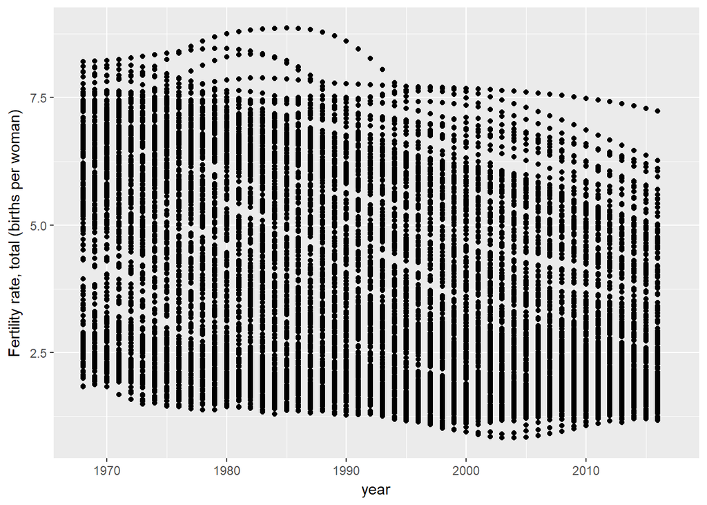

```r
library(ggplot2)
df %>%
  ggplot(mapping = aes(x=year,y=`Fertility rate, total (births per woman)`)) +
    geom_point()
```

It is very difficult to perform any kind of analysis on this data, because the plot is so crowded and there’s no way to tell trends or distributions. While graphical methods like ggplot are great tools to visualizing data, it is still the responsibility of the data scientist to understand what makes a graph readable. One important aspect of making a graph is not overcrowding the graph with too many things too look at. It is important for graphs to be clear in what they are trying to convey.  
Let’s try the same plot again with a couple added features:

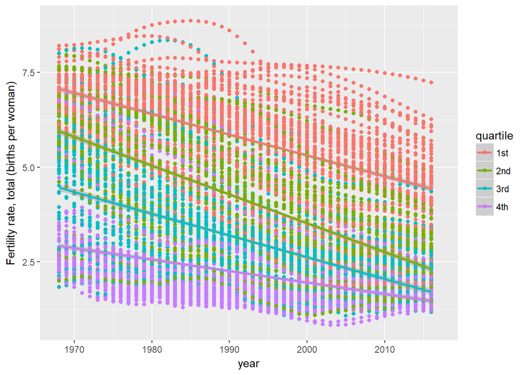

```r
library(ggplot2)
df %>%
  subset(!is.na(quartile))%>%
  ggplot(mapping = aes(x=year,y=`Fertility rate, total (births per woman)`,color=quartile, na.rm=TRUE)) +
    geom_point() + geom_smooth(method=lm)
```

While the graph still has just as many points, it is much more readable and we can actually make some hypotheses with it. Firstly, looking at the slope of each best fit line shows that we can suppose that as year increases, fertility decreases. Additionally, the clear blocks of data and differences between the lines of best fit for the colored quartiles means that we can suppose that fertility and GDP are somehow related.